# script projet stat

Killian Comby

2024-01-31

## Packages et Librairie

```r
if (!require("ggplot2")) install.packages("ggplot2")
if (!require("dplyr")) install.packages("dplyr")
if (!require("corrplot")) install.packages("corrplot")
library(dplyr)
library(ggplot2)
library(corrplot)
```

## Data Import

```r
data_merlan = read.csv2(file = "../Donnees/Données Merlan.csv", sep = ",")
```

```r
str(data_merlan)
```

```
## 'data.frame':    2623 obs. of  26 variables:
##  $ X            : chr  "3" "4" "5" "6" ...
##  $ ID           : chr  "1993_1_889_26" "1993_1_886_23" "1993_1_884_21" "1993_1_867_4" ...
##  $ Long         : chr  "-2.658" "-2.6255" "-2.6128" "-2.5757" ...
##  $ Lat          : chr  "47.4595" "47.4805" "47.4618" "47.4838" ...
##  $ Year         : int  1993 1993 1993 1993 1993 1993 1993 1993 1993 1993 ...
##  $ Month        : int  9 9 9 9 9 9 9 9 9 9 ...
##  $ Origin       : chr  "NURSE" "NURSE" "NURSE" "NURSE" ...
##  $ Surface      : chr  "0.005277" "0.005592" "0.006063" "0.006051" ...
##  $ Species      : chr  "Merlangius merlangus" "Merlangius merlangus" "Merlangius merlangus" "Merlangius merlangus" ...
##  $ Abundance    : int  0 0 0 0 0 0 0 0 0 0 ...
##  $ Density      : chr  "0" "0" "0" "0" ...
##  $ bathymetry   : chr  "-9.26594257354736" "-8.4555549621582" "-7.52666616439819" "-6.54333305358887" ...
##  $ substrat     : int  6 6 6 6 6 6 6 2 2 6 ...
##  $ chl_mean     : chr  "10.2070541381836" "10.40549659729" "10.6039390563965" "10.7031574249268" ...
##  $ nppv_mean    : chr  "98.5897064208984" "77.8119277954102" "57.0341529846191" "46.6454925537109" ...
##  $ o2_mean      : chr  "111.67113494873" "111.133460998535" "110.59578704834" "110.326950073242" ...
##  $ o2_cv        : chr  "5.54443550109863" "5.64739465713501" "5.75035381317139" "5.80183219909668" ...
##  $ o2_perc_25   : chr  "107.706871032715" "107.114814758301" "106.522758483887" "106.226737976074" ...
##  $ temp_mean    : chr  "15.9493093490601" "16.3252792358398" "16.7012500762939" "16.8892307281494" ...
##  $ temp_cv      : chr  "9.39767169952393" "9.19299602508545" "8.98832035064697" "8.88598537445068" ...
##  $ temp_perc_90 : chr  "17.9794044494629" "18.1636714935303" "18.347936630249" "18.4400691986084" ...
##  $ sali_mean    : chr  "32.7378997802734" "31.5520820617676" "30.3662643432617" "29.7733669281006" ...
##  $ sali_cv      : chr  "5.28708457946777" "5.25600385665894" "5.2249231338501" "5.20938301086426" ...
##  $ sali_tresh_10: chr  "0" "0" "0" "0" ...
##  $ sali_perc_90 : chr  "34.7983741760254" "33.6187744140625" "32.4391746520996" "31.8493881225586" ...
##  $ wave_mean    : int  3 3 3 2 3 3 3 3 2 3 ...
```

On modifie les types des variables pour qu’ils soient plus pertinents.

On passe `Year`, `Month` et `Origin` et `Species` en facteurs.

Attention cependant à ne pas passer `Lat` et `Long` en numeric car on perdrait des chriffres significatis.

```r
# On transforme les données de type non numériques en type numérique
data_merlan = data_merlan %>%
  mutate(
    Surface = as.numeric(Surface),
    Density = as.numeric(Density),
    bathymetry = as.numeric(bathymetry),
    chl_mean = as.numeric(chl_mean),
    nppv_mean = as.numeric(nppv_mean),
    o2_mean = as.numeric(o2_mean),
    o2_cv = as.numeric(o2_cv),
    o2_perc_25 = as.numeric(o2_perc_25),
    temp_mean = as.numeric(temp_mean),
    temp_cv = as.numeric(temp_cv),
    temp_perc_90 = as.numeric(temp_perc_90),
    sali_mean = as.numeric(sali_mean),
    sali_cv = as.numeric(sali_cv),
    sali_perc_90 = as.numeric(sali_perc_90)
  )

# Et les variables nécessaires en facteurs
# Converting a variable into an ordered factor with specified levels
data_merlan$Year <- factor(data_merlan$Year)
data_merlan$Month <- factor(data_merlan$Month)
data_merlan$Origin <- factor(data_merlan$Origin)
data_merlan$Species <- factor(data_merlan$Species)
```

Comme la première colonne est et restera un mystère, on va s’en débarasser pour le reste de l’étude :

```r
data_merlan = data_merlan %>% select(-X)
```

L’espèce étudiée est également unique (Merlangius merlangus), on supprime cette variable. On pourra la réintroduire si l’on compare merlan et sole.

```r
data_merlan = data_merlan %>% select(-Species)
```

De surcroît, la variable `sali_tresh_10` comportant beaucoup de valeurs nulles nous allons l’éliminer

```r
 count = data_merlan[data_merlan$sali_tresh_10!="0","sali_tresh_10"]
 length(count)
```

```
## [1] 198
```

(Il y a 198 valeurs non-nulles sur les 2623 observations soit 7.5% des observations)

```r
library(dplyr)
data_merlan = data_merlan %>% select(-sali_tresh_10)
```

```r
summary(data_merlan)
```

```
##       ID                Long               Lat                 Year
##  Length:2623        Length:2623        Length:2623        2019   : 165
##  Class :character   Class :character   Class :character   2017   : 157
##  Mode  :character   Mode  :character   Mode  :character   2018   : 155
##                                                           2009   : 148
##                                                           2020   : 144
##                                                           2010   : 141
##                                                           (Other):1713
##  Month        Origin        Surface           Abundance          Density
##  8 : 504   DCE   : 460   Min.   :0.000948   Min.   :  0.000   Min.   :  0.00
##  9 :1202   NURSE :1563   1st Qu.:0.003891   1st Qu.:  0.000   1st Qu.:  0.00
##  10: 251   ORHAGO: 600   Median :0.004488   Median :  0.000   Median :  0.00
##  11: 579                 Mean   :0.059738   Mean   :  4.978   Mean   : 11.57
##  12:  87                 3rd Qu.:0.018584   3rd Qu.:  1.000   3rd Qu.:  2.61
##                          Max.   :1.287147   Max.   :207.000   Max.   :519.58
##
##    bathymetry         substrat        chl_mean         nppv_mean
##  Min.   :-49.990   Min.   :2.000   Min.   : 0.2181   Min.   :  6.00
##  1st Qu.:-20.353   1st Qu.:4.000   1st Qu.: 2.6275   1st Qu.: 45.86
##  Median :-10.320   Median :5.000   Median : 4.3911   Median : 77.81
##  Mean   :-14.548   Mean   :4.915   Mean   : 6.3286   Mean   : 94.72
##  3rd Qu.: -4.946   3rd Qu.:6.000   3rd Qu.:10.1910   3rd Qu.:122.72
##  Max.   : -1.050   Max.   :6.000   Max.   :16.7564   Max.   :742.50
##
##     o2_mean           o2_cv         o2_perc_25       temp_mean
##  Min.   : 92.15   Min.   :1.041   Min.   : 87.99   Min.   :10.72
##  1st Qu.:103.51   1st Qu.:2.312   1st Qu.:101.60   1st Qu.:15.41
##  Median :107.02   Median :3.853   Median :104.97   Median :17.32
##  Mean   :107.82   Mean   :4.196   Mean   :104.52   Mean   :17.27
##  3rd Qu.:112.36   3rd Qu.:5.994   3rd Qu.:107.39   3rd Qu.:19.39
##  Max.   :125.12   Max.   :9.333   Max.   :119.06   Max.   :23.00
##
##     temp_cv        temp_perc_90     sali_mean         sali_cv
##  Min.   : 1.071   Min.   :11.39   Min.   : 4.318   Min.   : 0.09003
##  1st Qu.: 9.468   1st Qu.:17.72   1st Qu.:30.805   1st Qu.: 1.30518
##  Median :11.660   Median :19.98   Median :32.630   Median : 2.75373
##  Mean   :11.118   Mean   :19.58   Mean   :30.852   Mean   : 5.50774
##  3rd Qu.:13.137   3rd Qu.:21.83   3rd Qu.:34.142   3rd Qu.: 4.66071
##  Max.   :19.653   Max.   :25.86   Max.   :35.712   Max.   :66.15328
##
##   sali_perc_90     wave_mean
##  Min.   : 8.24   Min.   :1.000
##  1st Qu.:32.25   1st Qu.:2.000
##  Median :33.75   Median :3.000
##  Mean   :32.14   Mean   :2.488
##  3rd Qu.:34.78   3rd Qu.:3.000
##  Max.   :35.89   Max.   :3.000
##
```

### ——————– DISTRIBUTION DES DONNEES ———————-

```
        A FAIRE :
        - afficher histogramme des données pour essayer de trouver leur distribution
        - mettre une courbe de loi normale sur chaque histogramme / affichezr la courbe de densité avec ggplot 2
```

### Plot des distributions des variables

**Pt pas besoin de voir distribution de ABundance et density car variables d’intêret donc supprimées pour matrice corrélation**

On regarde la distribution des variables. Pour cela, on regarde la distribution des variables d’une même catégorie. On cherche à déterminer si les variables suivent une loi normale afin de choisir par la suite la meilleure manière de calculer les corrélations entre variables.

**Variables cibles :**

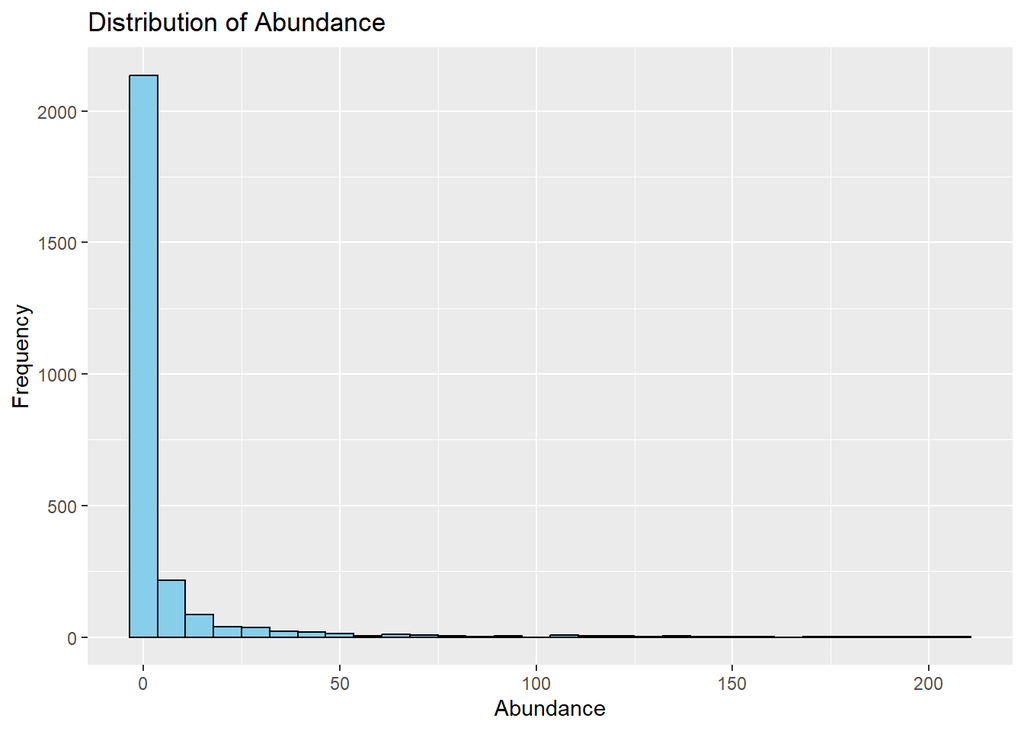

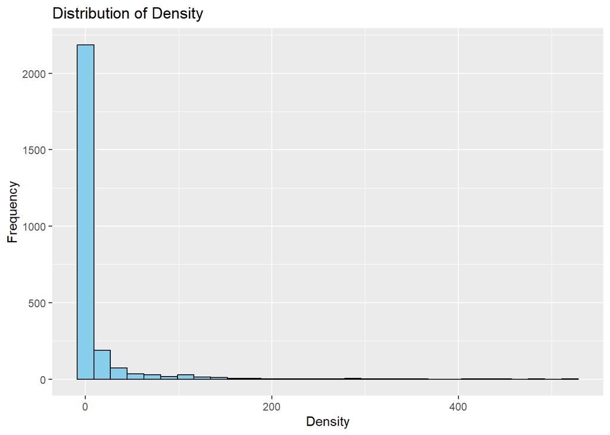

```r
# afficher distribution des variables
variable_names_temp <- c("Abundance", "Density")

for (var_name in variable_names_temp) {
  print(ggplot(data_merlan, aes_string(x = var_name)) +
          geom_histogram(bins = 30, fill = "skyblue", color = "black") +
          #geom_density(alpha = 0.5, fill = "darkblue") + # Pour ajouter une densité
          ggtitle(paste("Distribution of", var_name)) +
          xlab(var_name) +
          ylab("Frequency"))
}
```

**Variables au pif :**

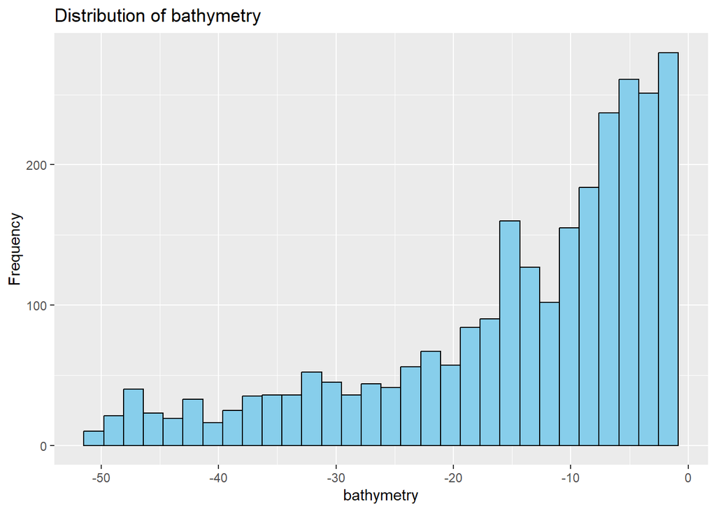

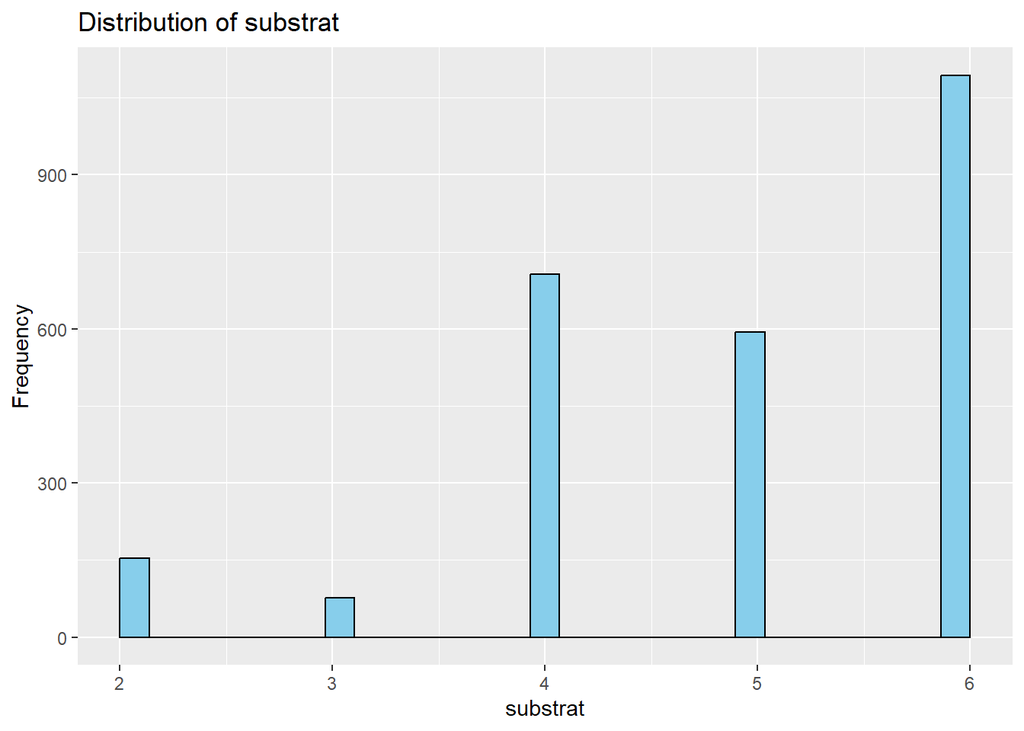

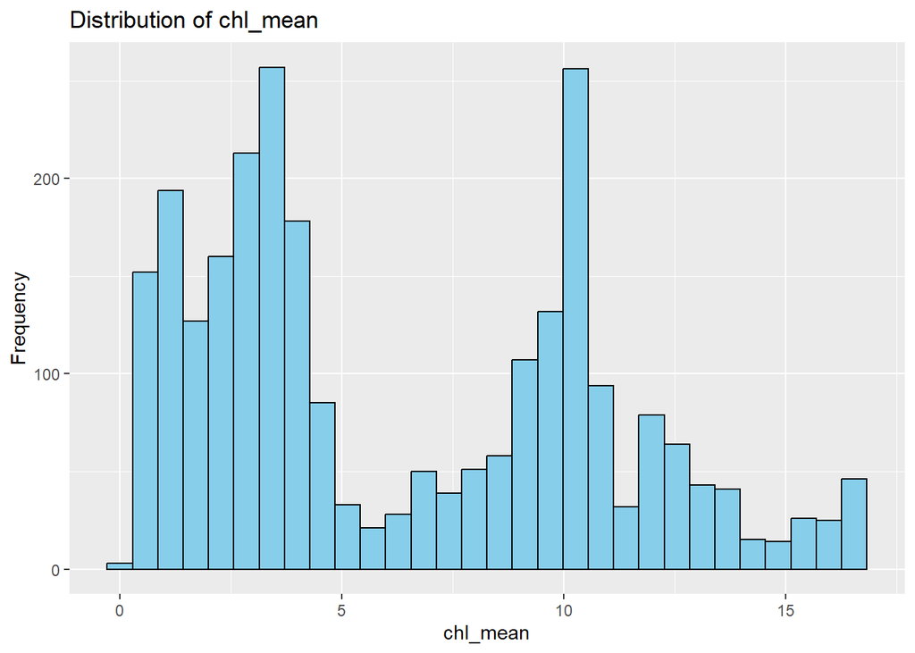

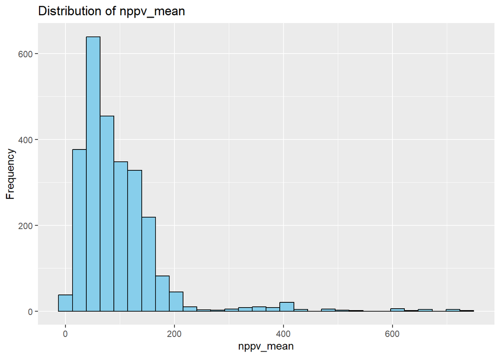

```r
# afficher distribution des variables
variable_names_temp <- c("bathymetry", "substrat", "chl_mean", "nppv_mean")

for (var_name in variable_names_temp) {
  print(ggplot(data_merlan, aes_string(x = var_name)) +
          geom_histogram(bins = 30, fill = "skyblue", color = "black") +
          #geom_density(alpha = 0.5, fill = "darkblue") + # Pour ajouter une densité
          ggtitle(paste("Distribution of", var_name)) +
          xlab(var_name) +
          ylab("Frequency"))
}
```

Lois a priori inconnues. Peut-être chi-2 sur nppv_mean

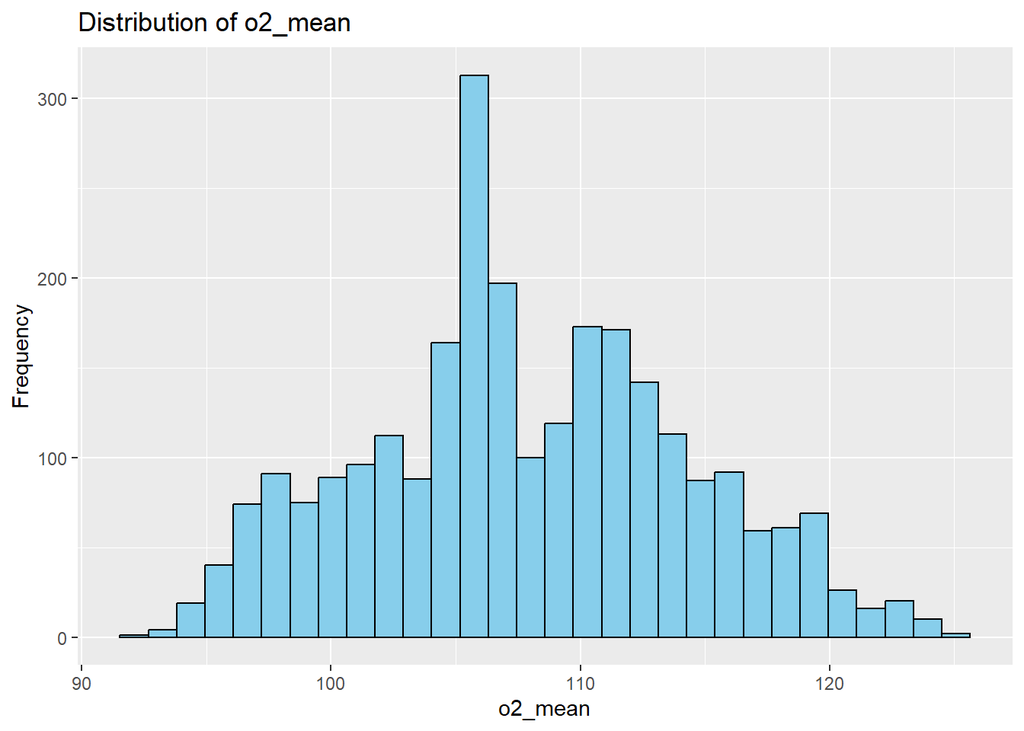

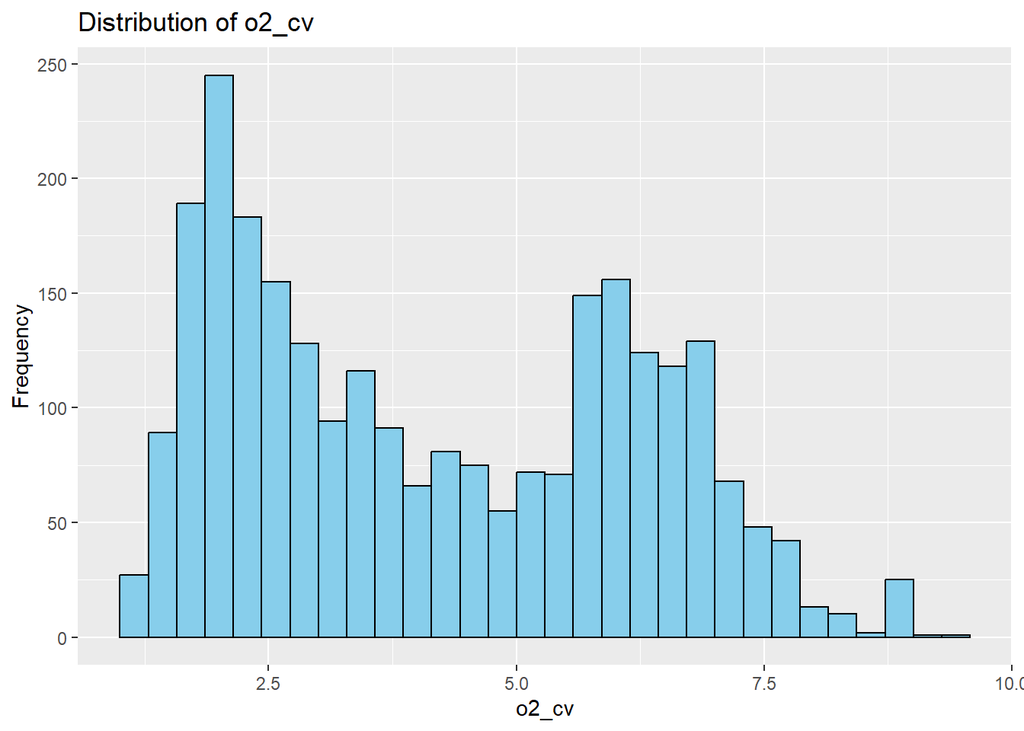

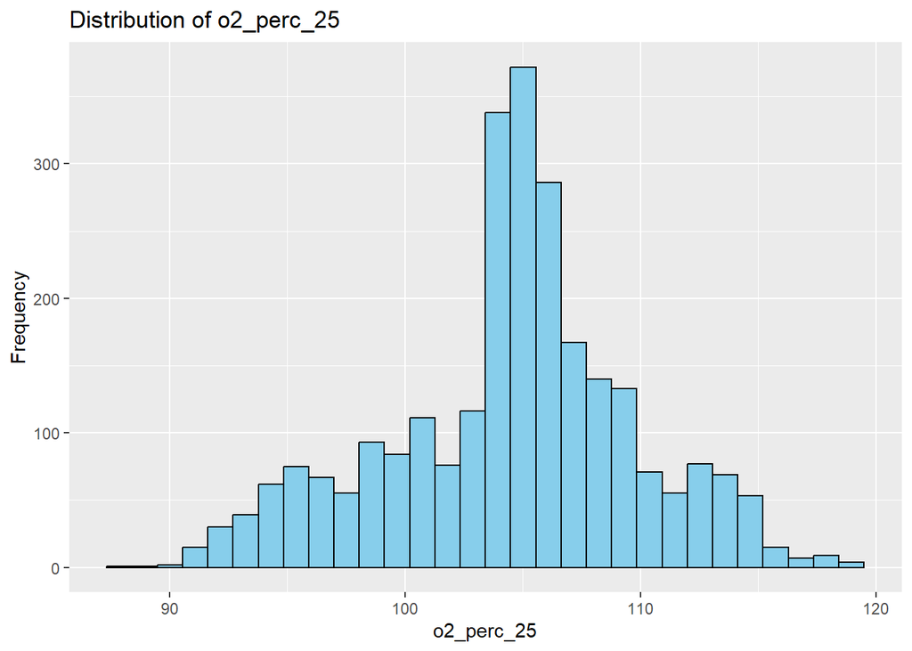

```r
# afficher distribution des variables
variable_names_temp <- c("o2_mean", "o2_cv", "o2_perc_25")

for (var_name in variable_names_temp) {
  print(ggplot(data_merlan, aes_string(x = var_name)) +
          geom_histogram(bins = 30, fill = "skyblue", color = "black") +
          #geom_density(alpha = 0.5, fill = "darkblue") + # Pour ajouter une densité
          ggtitle(paste("Distribution of", var_name)) +
          xlab(var_name) +
          ylab("Frequency"))
}
```

Lois inconnues a priori.

**Température :**

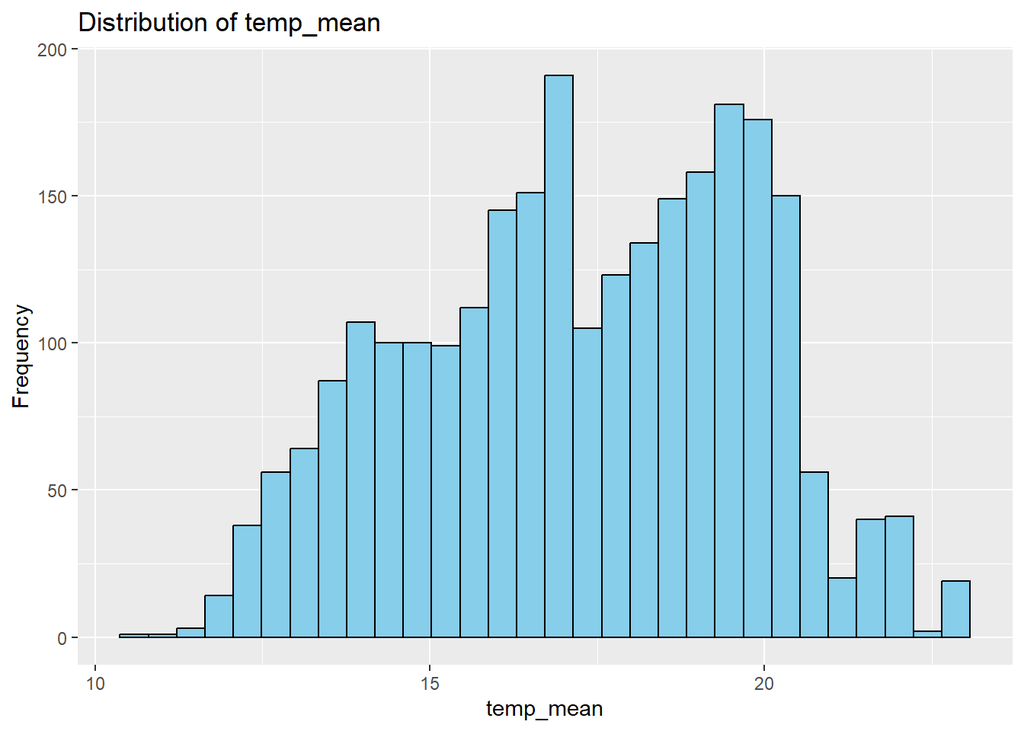

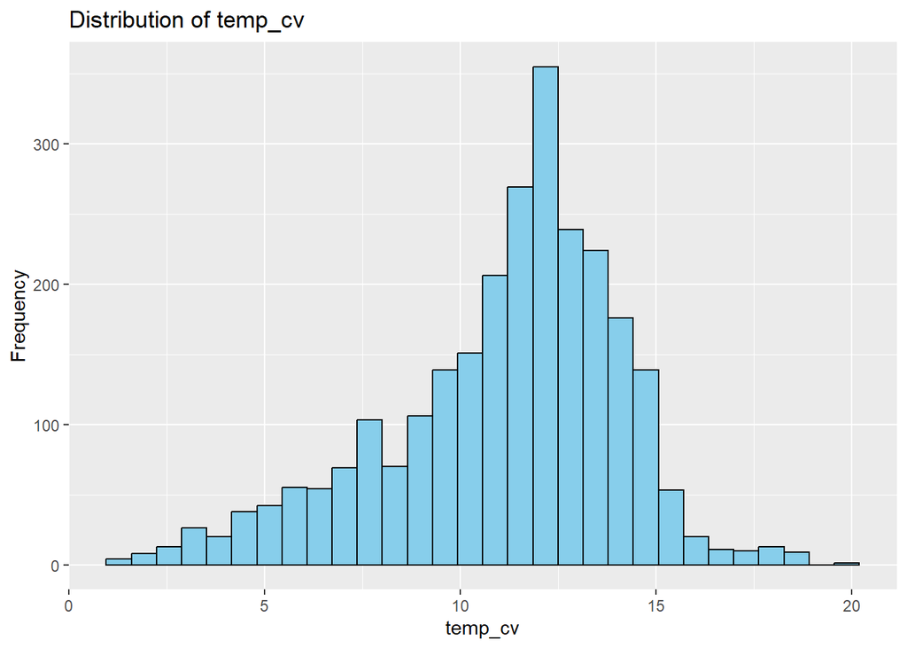

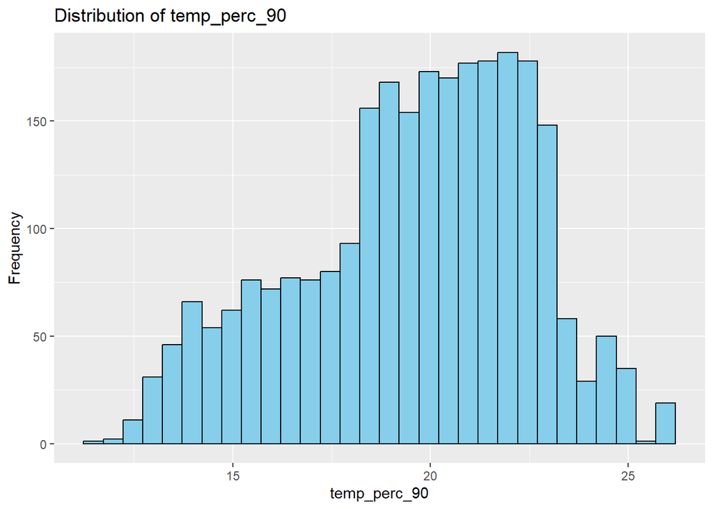

```r
# afficher distribution des variables
variable_names_temp <- c("temp_mean", "temp_cv", "temp_perc_90")

for (var_name in variable_names_temp) {
  print(ggplot(data_merlan, aes_string(x = var_name)) +
          geom_histogram(bins = 30, fill = "skyblue", color = "black") +
          #geom_density(alpha = 0.5, fill = "darkblue") + # Pour ajouter une densité
          ggtitle(paste("Distribution of", var_name)) +
          xlab(var_name) +
          ylab("Frequency"))
}
```

A priori aucune loi connue ne ressort. Peut-être que `tmp_cv` se rapproche d’une loi normale mais ce n’est pas convaincant.

**Salinité :**

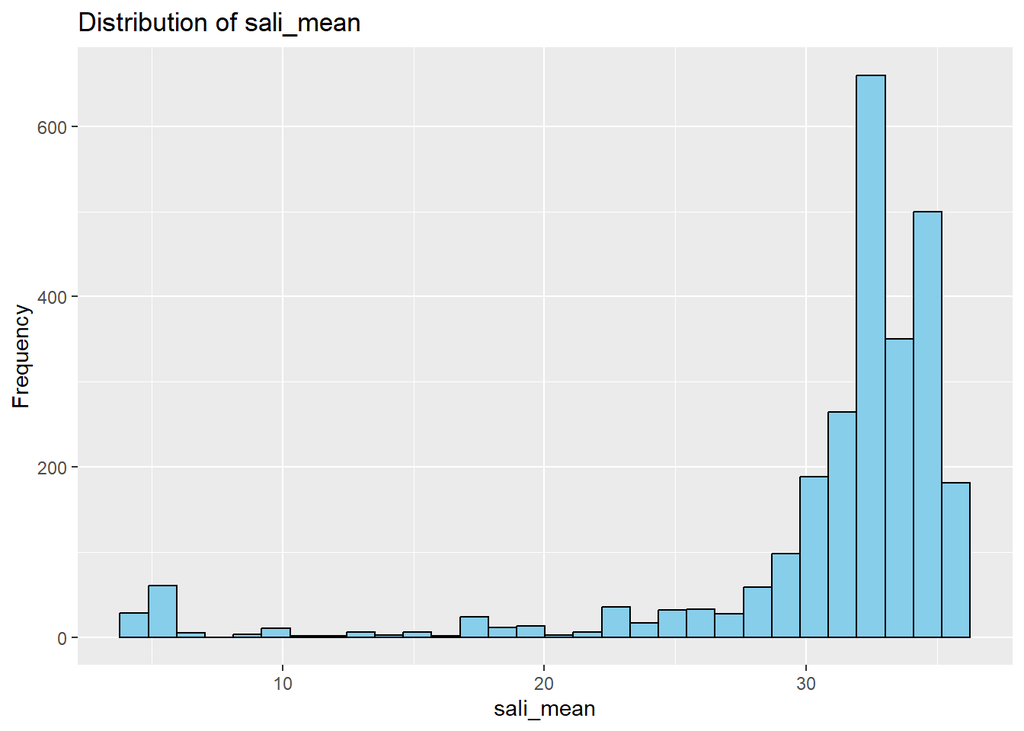

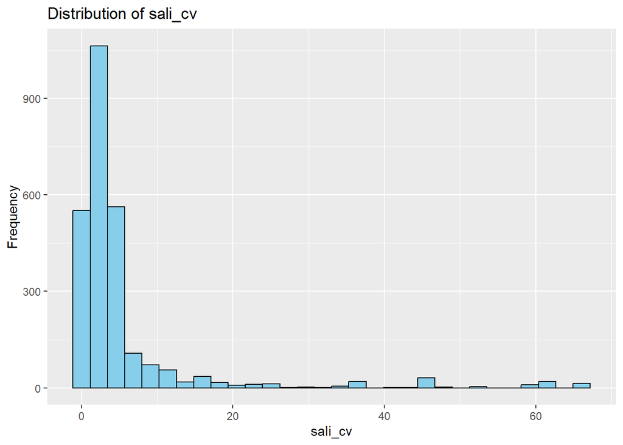

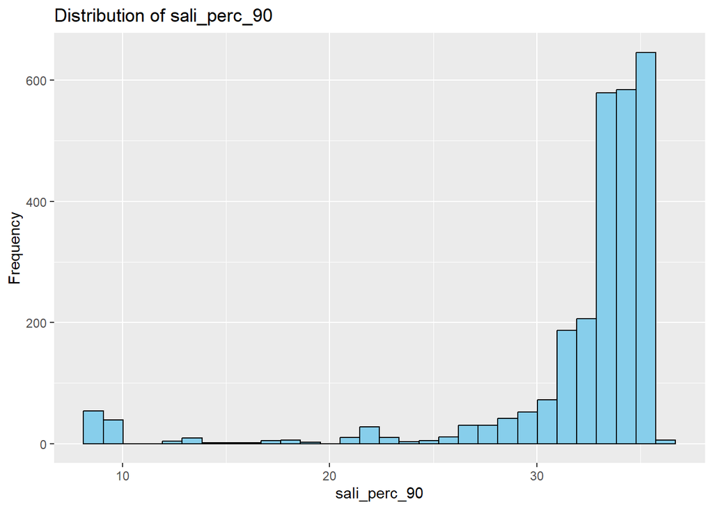

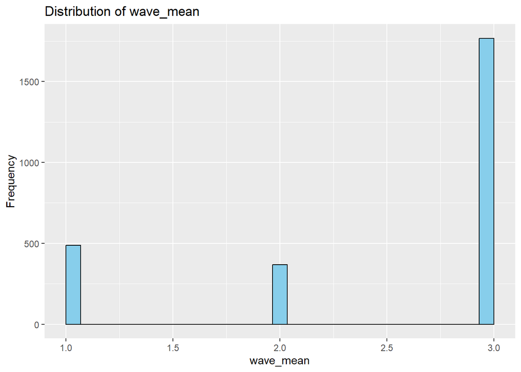

```r
# afficher distribution des variables
variable_names <- c("sali_mean", "sali_cv", "sali_perc_90", "wave_mean")

for (var_name in variable_names) {
  print(ggplot(data_merlan, aes_string(x = var_name)) +
          geom_histogram(bins = 30, fill = "skyblue", color = "black") +
          ggtitle(paste("Distribution of", var_name)) +
          xlab(var_name) +
          ylab("Frequency"))
}
```

Pareil : pas de loi normale en vue

### ——————– CORRELATIONS ———————-

### Aperçu de la corrélation entre les données :

Choix des variables : les variables du mois et de l’année sont à retirer car nous n’avons pas de cartes pour projeter ces données. L’abondance et la densité sont également à retirer puisqu’il s’agira de la variable réponse.

```r
# Suppression des variables non utiles pour la matrice de corrélation
data_corr <- data_merlan %>% select(c(-Year, -Month, -Abundance, -Density))

# Conservation des données numériques
data_corr <- data_corr %>% select_if(is.numeric)
```

```r
correlation_matrix_spearman = cor(data_corr, method = "spearman")
correlation_matrix_pearson = cor(data_corr, method = "pearson")
correlation_matrix_kendall = cor(data_corr, method = "kendall")

# Éxécuter la ligne ci-dessous pour n'avoir que la correlation en fonction de la densité :
#correlation_matrix["Density",]
```

On peut faire un plot pour mieux se rendre compte de la relation entre les donneés :

On affiche d’abord la matrice de corrélation calculée avec le test de Pearson (comme Hugo l’avait fait). Cependant, le test de Pearson suppose que les données suivent une loi normale, ce qui n’est pas le cas. On préfère donc retenir les matrices de corrélation calculées avec le test de Spearman ou de Kendall, qui sont eux indépendants de la distribution des données.

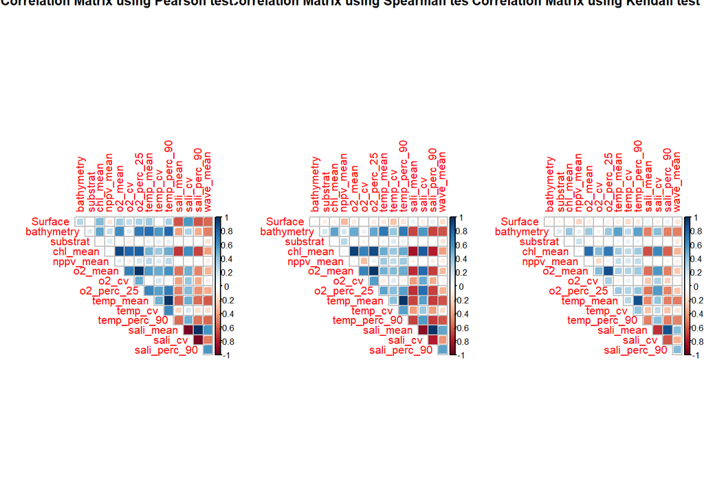

```r
# Visualisation avec des carrés
par(mfrow=c(1,3))

# Pearson
corrplot(
  correlation_matrix_pearson,
  method = "square",
  addshade = "positive",
  diag = FALSE,
  type = "upper",
  #order = 'AOE',
  title = "Correlation Matrix using Pearson test"
  )

#  Spearman
corrplot(
  correlation_matrix_spearman,
  method = "square",
  addshade = "positive",
  diag = FALSE,
  type = "upper",
  #order = 'AOE',
  title = "Correlation Matrix using Spearman test"
  )

# Kendall
corrplot(
  correlation_matrix_kendall,
  method = "square",
  addshade = "positive",
  diag = FALSE,
  type = "upper",
  #order = 'AOE',
  title = "Correlation Matrix using Kendall test"
  )
```

```r
par(mfrow=c(1,1))
```

On représente aussi avec les valeurs des corrélation, mais on voit rien (même avec 1 image)

[figure not shown]

```r
# Avec la valeur des corrélation
par(mfrow=c(1,3))

# Pearson
corrplot(
  correlation_matrix_pearson,
  method = "number",
  type = "upper",
  addshade = "positive",
  diag = FALSE,
  #order = 'AOE',
  title = "Correlation Matrix using Pearson test"
  )
# Spearman
corrplot(
  correlation_matrix_spearman,
  method = "number",
  type = "upper",
  addshade = "positive",
  diag = FALSE,
  #order = 'AOE',
  title = "Correlation Matrix using Spearman test"
  )

# Kendall
corrplot(
  correlation_matrix_kendall,
  method = "number",
  type = "upper",
  addshade = "positive",
  diag = FALSE,
  #order = 'AOE',
  title = "Correlation Matrix using Kendall test"
  )
```

```r
par(mfrow=c(1,1))
```

#### Discussion sur la matrice de corrélation

Certaines corrélations sont différentes entre Pearson et Spearman/Kendall, notamment pour les variables `surface` et `bathymetry`. Les matrices de Spearman et Kendall révèlent les mêmes corrélations, bien que Kendall soit plus edulcorée en renvoyant des corrélations moins fortes.

```
        A FAIRE : sélectionner les variables qu'on conserve en collant le plus possible avec celles d'Hugo
```

#### Test VIF

To do so, we must make a linear model using variables from the data set.

```r
# One model using the abundance as the response variable
abundance_model = lm(Abundance ~ bathymetry+substrat+chl_mean+nppv_mean+o2_mean+temp_mean+sali_mean+wave_mean, data = data_merlan)

# Another similar model using the density instead as the response variable
density_model = lm(Density ~ bathymetry+substrat+chl_mean+nppv_mean+o2_mean+temp_mean+sali_mean+wave_mean, data = data_merlan)
```

We can visualize the models:

```r
summary(abundance_model)
```

```
##
## Call:
## lm(formula = Abundance ~ bathymetry + substrat + chl_mean + nppv_mean +
##     o2_mean + temp_mean + sali_mean + wave_mean, data = data_merlan)
##
## Residuals:
##     Min      1Q  Median      3Q     Max
## -15.267  -5.892  -2.457   0.391 197.694
##
## Coefficients:
##               Estimate Std. Error t value Pr(>|t|)
## (Intercept) -60.020113  14.325403  -4.190 2.88e-05 ***
## bathymetry    0.054116   0.046565   1.162 0.245279
## substrat      2.077611   0.299375   6.940 4.93e-12 ***
## chl_mean      0.094475   0.265559   0.356 0.722050
## nppv_mean    -0.007282   0.004462  -1.632 0.102823
## o2_mean       0.621151   0.164614   3.773 0.000165 ***
## temp_mean    -1.246418   0.279371  -4.462 8.48e-06 ***
## sali_mean     0.173535   0.107384   1.616 0.106210
## wave_mean     1.956565   0.599973   3.261 0.001124 **
## ---
## Signif. codes:  0 '***' 0.001 '**' 0.01 '*' 0.05 '.' 0.1 ' ' 1
##
## Residual standard error: 16.99 on 2614 degrees of freedom
## Multiple R-squared:  0.06935,    Adjusted R-squared:  0.0665
## F-statistic: 24.35 on 8 and 2614 DF,  p-value: < 2.2e-16
```

We notice that 5 of the 9 coefficents are significant, whereas variables `bathymetry`, `chl_mean`, `nppv_mean` and `sali_mean` cannot explain the model. Further, the R-squared is really low, which challenges the model. **So we could maybe delete them.** The model will be the same as these variables are unsignificant. We decide to maintain them in the VIF test to see if there is a correlation.

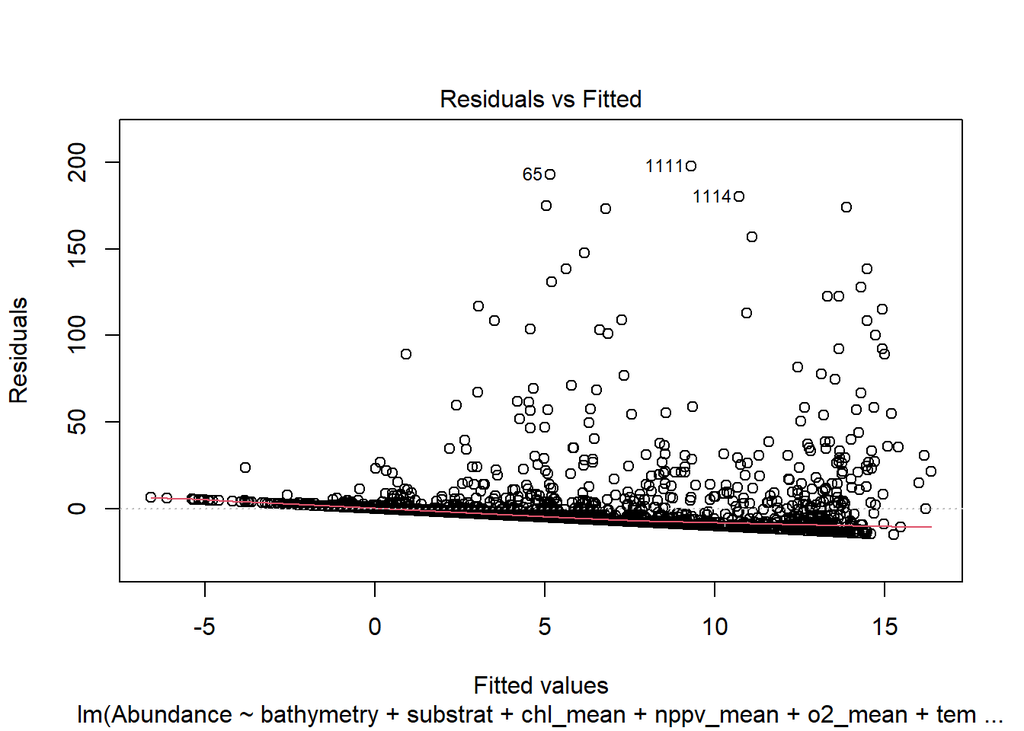

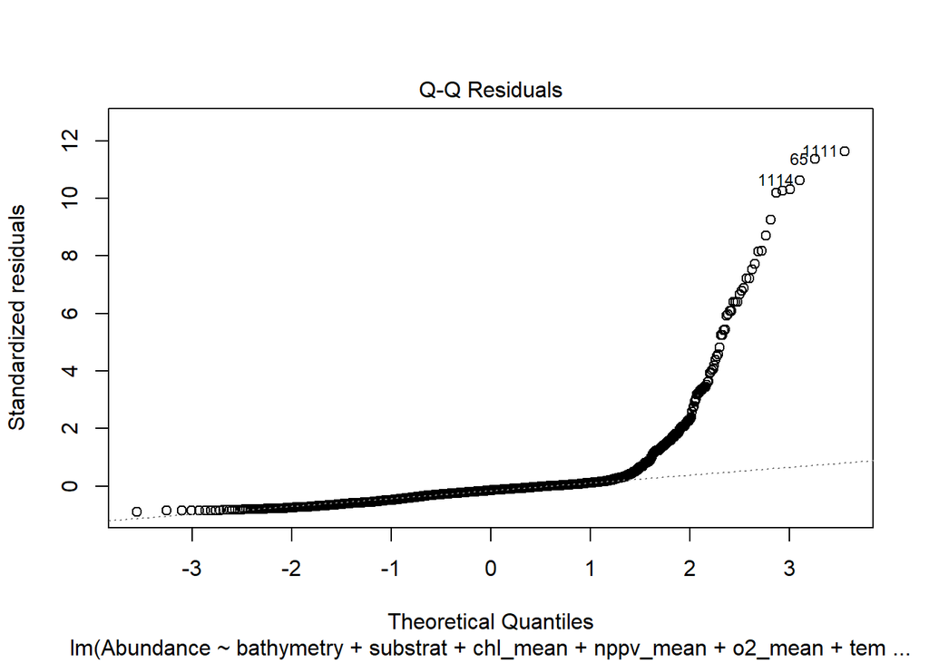

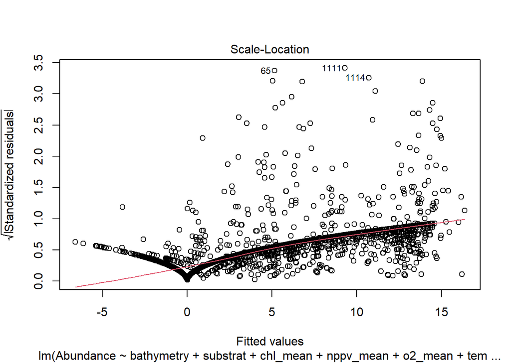

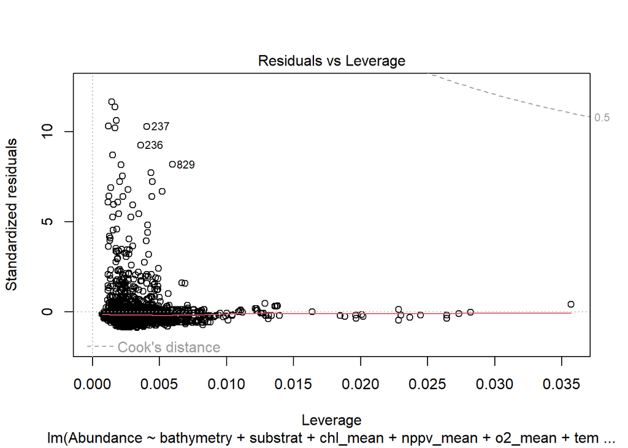

```r
plot(abundance_model)
```

```r
summary(density_model)
```

```
##
## Call:
## lm(formula = Density ~ bathymetry + substrat + chl_mean + nppv_mean +
##     o2_mean + temp_mean + sali_mean + wave_mean, data = data_merlan)
##
## Residuals:
##    Min     1Q Median     3Q    Max
## -35.57 -14.04  -5.70   0.82 497.78
##
## Coefficients:
##               Estimate Std. Error t value Pr(>|t|)
## (Intercept) -136.67630   34.07658  -4.011 6.22e-05 ***
## bathymetry     0.18362    0.11077   1.658 0.097488 .
## substrat       5.00933    0.71214   7.034 2.55e-12 ***
## chl_mean       0.54033    0.63170   0.855 0.392432
## nppv_mean     -0.02000    0.01062  -1.884 0.059615 .
## o2_mean        1.36912    0.39158   3.496 0.000479 ***
## temp_mean     -2.91034    0.66456  -4.379 1.24e-05 ***
## sali_mean      0.59493    0.25544   2.329 0.019933 *
## wave_mean      3.64441    1.42719   2.554 0.010719 *
## ---
## Signif. codes:  0 '***' 0.001 '**' 0.01 '*' 0.05 '.' 0.1 ' ' 1
##
## Residual standard error: 40.43 on 2614 degrees of freedom
## Multiple R-squared:  0.07105,    Adjusted R-squared:  0.06821
## F-statistic: 24.99 on 8 and 2614 DF,  p-value: < 2.2e-16
```

Now onto the `vif` test using the `car` package

```r
# Load the library
require(car)
# calculate the VIF
cat("Abundance Model VIF :\n\n")
```

```
## Abundance Model VIF :
```

```r
vif(abundance_model)
```

```
## bathymetry   substrat   chl_mean  nppv_mean    o2_mean  temp_mean  sali_mean
##   3.014015   1.074309  12.627207   1.167041  10.315732   4.403299   4.073206
##  wave_mean
##   2.033177
```

```r
cat("\nDensity Model VIF :\n\n")
```

```
##
## Density Model VIF :
```

```r
vif(density_model)
```

```
## bathymetry   substrat   chl_mean  nppv_mean    o2_mean  temp_mean  sali_mean
##   3.014015   1.074309  12.627207   1.167041  10.315732   4.403299   4.073206
##  wave_mean
##   2.033177
```

*Plotting the results:*

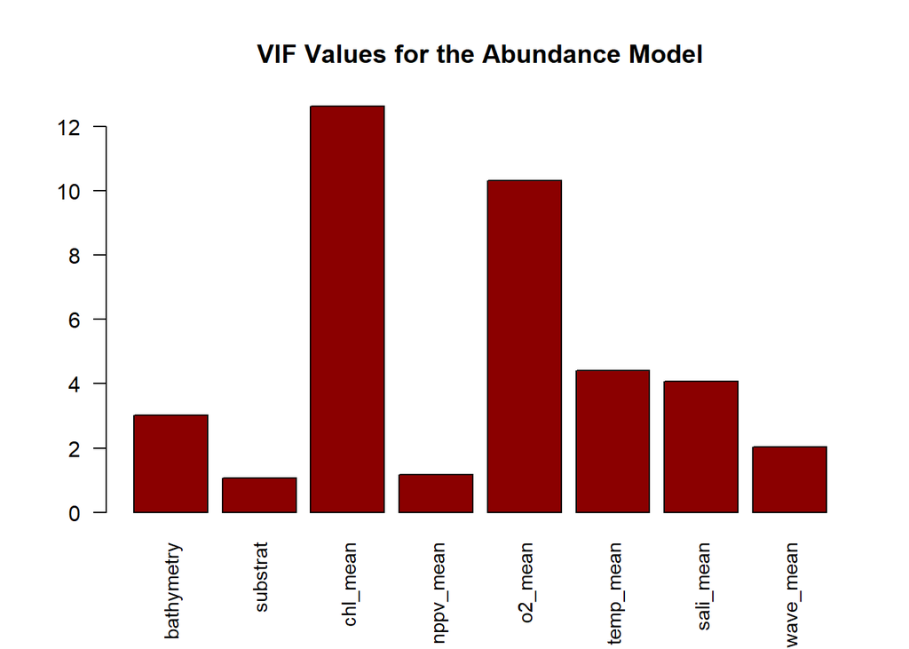

```r
barplot(vif(abundance_model), main = "VIF Values for the Abundance Model",
        horiz = FALSE, col = "darkred", las=2, cex.names=0.9)
```

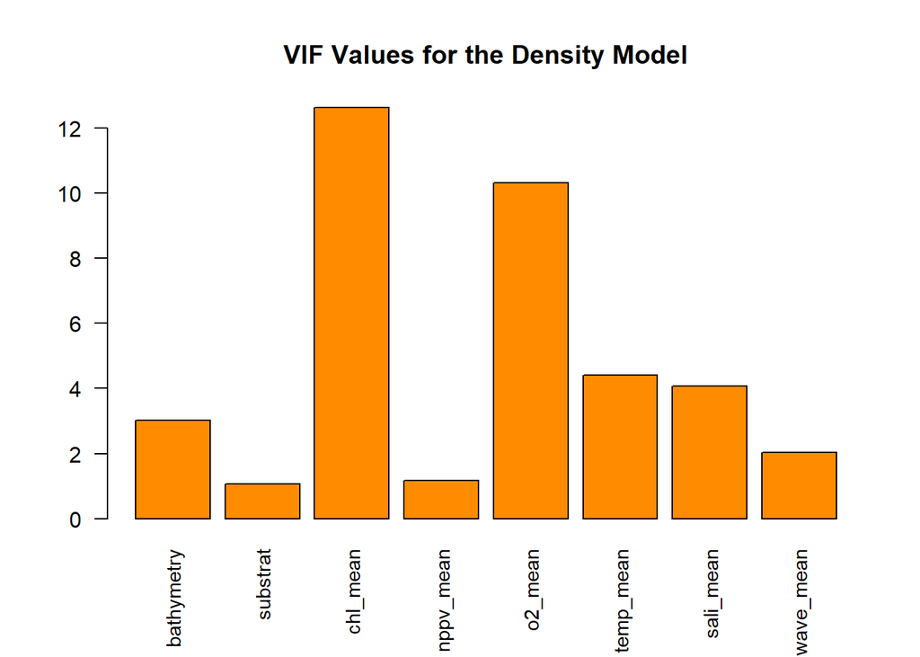

```r
barplot(vif(density_model), main = "VIF Values for the Density Model",
        horiz = FALSE, col = "darkorange", las=2, cex.names=0.9)
```

*Interpretation:*

To interpret the VIF test, we will use the following modalities:

- A VIF of 1 indicates no multicollinearity.
- A VIF between 1 and 5 is generally acceptable.
- A VIF between 6 and 10 begins to be critical
- A VIF above 10 indicates problematic multicollinearity between variables.

Funny enough, the VIF values for the abundance and the density models are exactly the same. So we make interpretation for both.

For other ones, their VIF is under 5 so we can consider the independance of the variables. The VIF of `substrat` and `nppw_mean` are particularly near to 1, indicates no multicollinearity.

```r
# One model using the abundance as the response variable
abundance_model_v2 = lm(Abundance ~ bathymetry+substrat+nppv_mean+sali_mean+wave_mean+o2_mean, data = data_merlan)
# Another similar model using the density instead as the response variable
density_model_v2 = lm(Density ~ substrat+nppv_mean+temp_mean+sali_mean+wave_mean+o2_mean, data = data_merlan)
```

```r
# Let's look at the model
cat("Abundance Model :\n\n")
```

```
## Abundance Model :
```

```r
summary(abundance_model_v2)
```

```
##
## Call:
## lm(formula = Abundance ~ bathymetry + substrat + nppv_mean +
##     sali_mean + wave_mean + o2_mean, data = data_merlan)
##
## Residuals:
##     Min      1Q  Median      3Q     Max
## -16.592  -5.985  -2.883   0.243 197.969
##
## Coefficients:
##               Estimate Std. Error t value Pr(>|t|)
## (Intercept) -92.684102   9.481965  -9.775  < 2e-16 ***
## bathymetry   -0.081203   0.038817  -2.092 0.036540 *
## substrat      2.130289   0.299655   7.109 1.50e-12 ***
## nppv_mean    -0.012753   0.004339  -2.939 0.003319 **
## sali_mean     0.279364   0.075848   3.683 0.000235 ***
## wave_mean     2.679921   0.576173   4.651 3.46e-06 ***
## o2_mean       0.667148   0.074116   9.001  < 2e-16 ***
## ---
## Signif. codes:  0 '***' 0.001 '**' 0.01 '*' 0.05 '.' 0.1 ' ' 1
##
## Residual standard error: 17.08 on 2616 degrees of freedom
## Multiple R-squared:  0.05933,    Adjusted R-squared:  0.05718
## F-statistic:  27.5 on 6 and 2616 DF,  p-value: < 2.2e-16
```

```r
cat("\nDensity Model :\n\n")
```

```
##
## Density Model :
```

```r
summary(density_model_v2)
```

```
##
## Call:
## lm(formula = Density ~ substrat + nppv_mean + temp_mean + sali_mean +
##     wave_mean + o2_mean, data = data_merlan)
##
## Residuals:
##    Min     1Q Median     3Q    Max
## -36.98 -14.11  -5.85   0.63 497.50
##
## Coefficients:
##               Estimate Std. Error t value Pr(>|t|)
## (Intercept) -184.31545   19.95700  -9.236  < 2e-16 ***
## substrat       5.10970    0.70470   7.251 5.43e-13 ***
## nppv_mean     -0.01915    0.01058  -1.810  0.07043 .
## temp_mean     -2.62802    0.48405  -5.429 6.18e-08 ***
## sali_mean      0.52435    0.18380   2.853  0.00437 **
## wave_mean      3.05612    1.38913   2.200  0.02789 *
## o2_mean        1.80111    0.15774  11.418  < 2e-16 ***
## ---
## Signif. codes:  0 '***' 0.001 '**' 0.01 '*' 0.05 '.' 0.1 ' ' 1
##
## Residual standard error: 40.44 on 2616 degrees of freedom
## Multiple R-squared:  0.06974,    Adjusted R-squared:  0.06761
## F-statistic: 32.69 on 6 and 2616 DF,  p-value: < 2.2e-16
```

Almost all the coefficients are highly significant.

```r
# calculate the VIF
cat("Abundance Model VIF :\n\n")
```

```
## Abundance Model VIF :
```

```r
vif(abundance_model_v2)
```

```
## bathymetry   substrat  nppv_mean  sali_mean  wave_mean    o2_mean
##   2.073715   1.065675   1.092441   2.011992   1.856529   2.070526
```

```r
cat("\nDensity Model VIF :\n\n")
```

```
##
## Density Model VIF :
```

```r
vif(density_model_v2)
```

```
##  substrat nppv_mean temp_mean sali_mean wave_mean   o2_mean
##  1.051311  1.158259  2.334599  2.107517  1.924930  1.672979
```

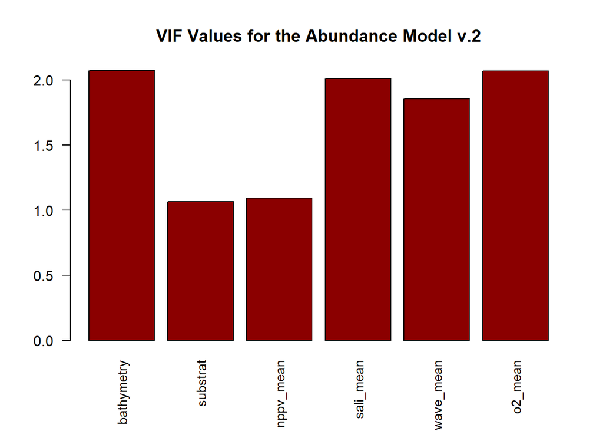

```r
# Plot the VIF values
barplot(vif(abundance_model_v2), main = "VIF Values for the Abundance Model v.2",
        horiz = FALSE, col = "darkred", las=2, cex.names=0.9)
```

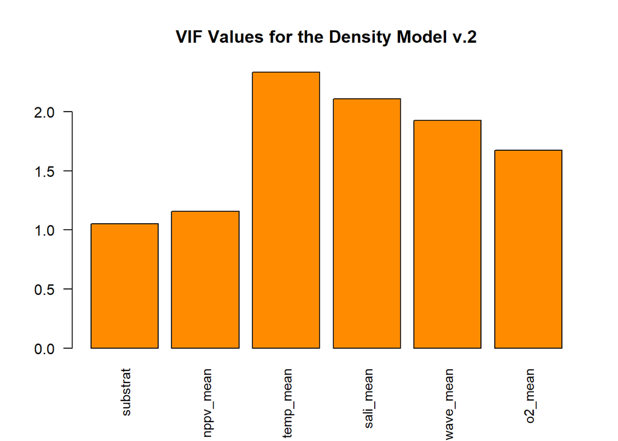

```r
barplot(vif(density_model_v2), main = "VIF Values for the Density Model v.2",
        horiz = FALSE, col = "darkorange", las=2, cex.names=0.9)
```

We obtain VIF values even closer to 1, meaning a no multicollinearity. We can also keep these variables to the rest of the study.

#### Installation du package pour les arbres boostés :

```r
if(!require(xgboost)){
  install.packages("xgboost")
}
# On charge la librairie
require(xgboost)
```

### Commencement des arbres de regréssion boostés

Passons à la création d’une `dcgMatrix` à partir de nos données :

```r
# Let's start by getting rid of all the variables that won't be useful for the regression tree
if(!(require(caret))){
  install.packages('caret')
}
require(caret)
```

Creation of the training data set and the testing data set :

```r
set.seed(123) # For reproductibility

# Let's reset numeric_data here just in case it has been modified somewhere else
numeric_data = data_merlan %>% select_if(is.numeric)

# Remove the Year and Month columns
numeric_data = numeric_data %>% select(-c(Surface,Abundance))

index <- createDataPartition(numeric_data$Density, p = 0.8, list=FALSE)

# Using the index to separate the data set
train_data = numeric_data[index, ] # Training Data
test_data = numeric_data[-index, ] # Test Data

# Let's check the size of our new data sets
nrow(train_data)
```

```
## [1] 2099
```

```r
nrow(test_data)
```

```
## [1] 524
```

```r
# Do not forget to extract Desnity from the dataset
train_data_label = unlist(train_data$Density)
train_data = train_data %>% select(-Density)
test_data_label = unlist(test_data$Density)
test_data = test_data %>% select(-Density)
```

Creating the `dcgMatrix` for the boosted regression tree method `xgboost`

```r
# Construction of the dcgMatrix object for the train dataset

dtrain <- xgb.DMatrix(data = as.matrix(train_data), label = train_data_label)
```

```r
# Construction of the dcgMatrix object for the test dataset

dtest <- xgb.DMatrix(data = as.matrix(test_data), label = test_data_label)
```

Trying to train the model with `dcgMatrix` :

```r
bstDMatrix <- xgboost(
  data = dtrain,
  max.depth = 6,
  eta = 1,
  nthread = 4,
  nrounds = 100,
  objective = "reg:squarederror")
```

Now onto a basic prediciton using XGBoost :

```r
pred <- predict(bstDMatrix, dtest)
```

Computing the RMSE to check the perfomrance of the prediction

```r
# RMSE
rmse <- sqrt(mean((pred - test_data_label)^2))

# Let's compute the range of our dataset to have a better understanding of the rmse value :
range = diff(range(test_data_label))

#
rmse_perc = (rmse/range)*100

cat("The Error (RMSE) percentage : ",rmse_perc)
```

```
## The Error (RMSE) percentage :  9.865021
```

Now we want to save the model, and visualize some of the trees !

```r
# Saving the model (including all trees)
xgb.save(bstDMatrix, "first_basic_model_xgboost.model")
```

```
## [1] TRUE
```

```r
# Loading the preivously saved model (for verification purpose)
bst_saved <- xgb.load("first_basic_model_xgboost.model")
```

```r
if(!(require(DiagrammeR))){
  install.packages("DiagrammeR")
}
require(DiagrammeR)

if(!(require(DiagrammeRsvg))){
  install.packages("DiagrammeRsvg")
}
require(DiagrammeRsvg)

if(!(require(rsvg))){
  install.packages("rsvg")
}
```

```
## Linking to librsvg 2.57.0
```

```r
require(rsvg)

# Visualization of trees 1, 41 and 99 (the tree index in xgboost model is zero-based)
# xgb.plot.tree(model = bst_saved, trees = c(0,40,98))
gr <- xgb.plot.tree(model = bst_saved,
                   trees = 98,
                   plot_width = 2400,
                   plot_height = 3600,
                   render = F,
                   feature_names = colnames(train_data)
                   )

# In order to create a valid graph, we must use the render = F option

export_graph(gr, '../Donnees/tree.png', width = 2400, height = 3600)
```

We can also use `xgb.ggplot.importance()` to directly visualize the variables’s importance :

Package Dependecies :

```r
if(!(require(Ckmeans.1d.dp))){
  install.packages("Ckmeans.1d.dp")
}
require(Ckmeans.1d.dp)
```

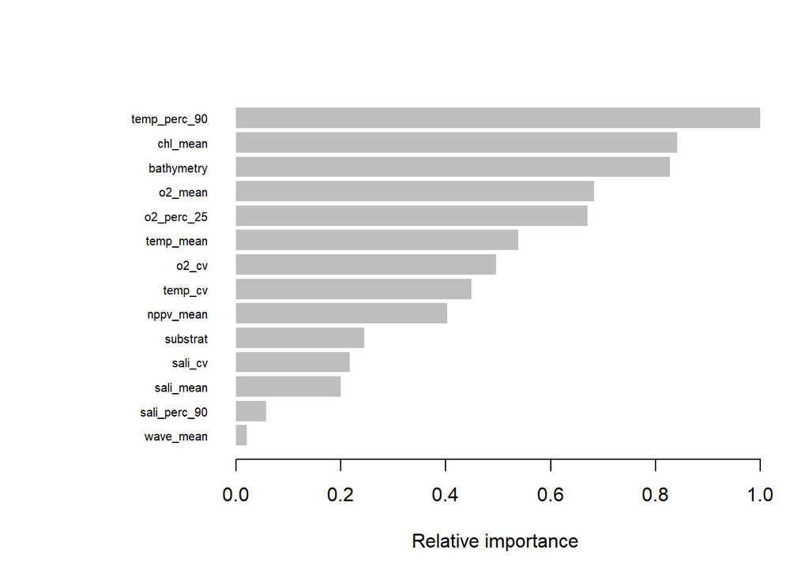

```r
importance_matrix <- xgb.importance(
  colnames(train_data), model = bst_saved
  )

xgb.plot.importance(importance_matrix, rel_to_first = TRUE, xlab = "Relative importance")
```

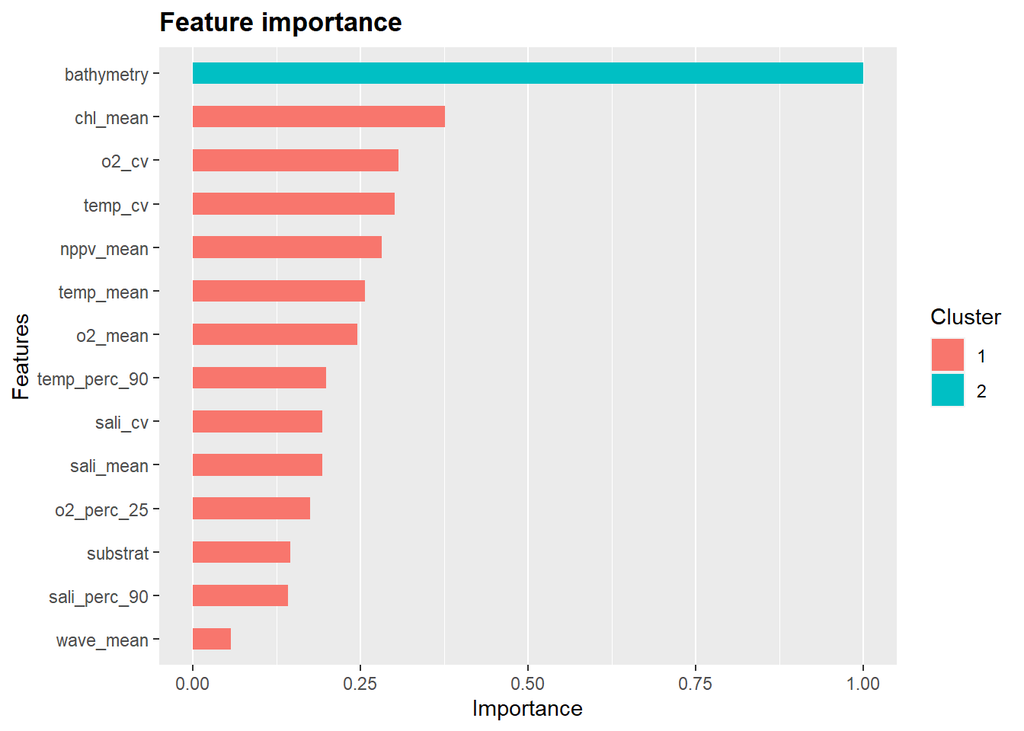

```r
(gg <- xgb.ggplot.importance(importance_matrix, measure = "Frequency", rel_to_first = TRUE))
```

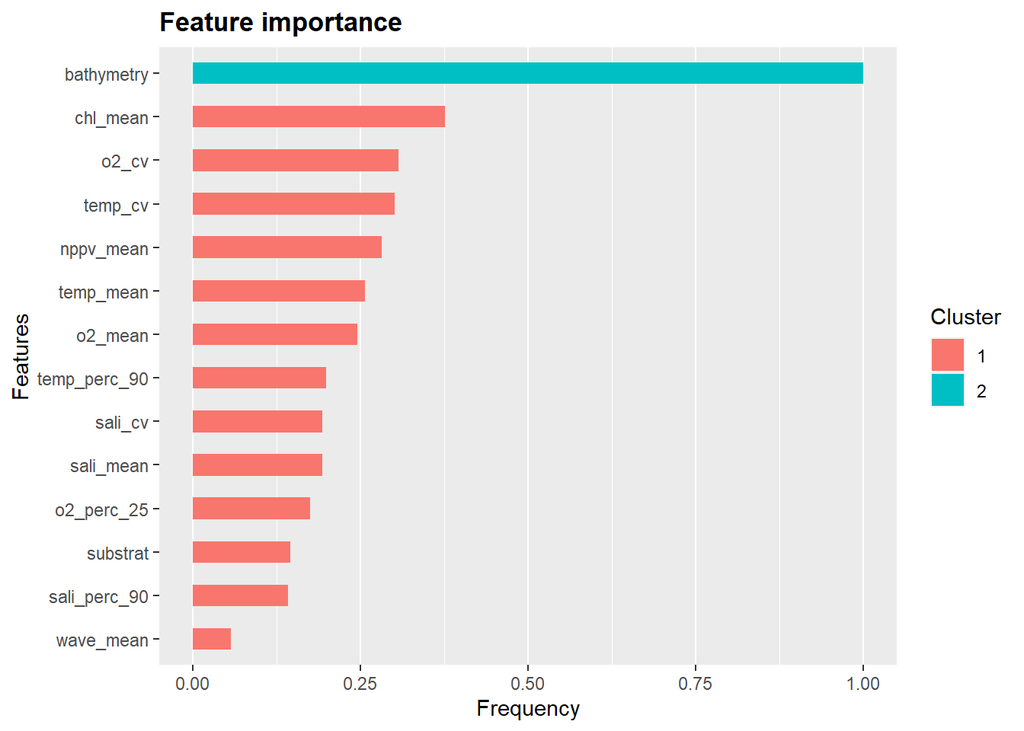

```r
gg + ggplot2::ylab("Frequency")
```